# Multiple Linear Regression Modelling

# Car Price Predictor

Winn Pham

October 11, 2023

### 1. Importing Libraries

```r
library(tools)
library(viridis)
library(tidyverse)
library(gridExtra)
```

```r
library(moments)
library(ggplot2)
library(reshape2)
library(corrplot)
library(Hmisc)
library(caTools)
```

## 2. Loading Dataset

```r
car_data <- read.csv("carprice.csv")
head(car_data)
```

```
##   car_ID symboling                  CarName fueltype aspiration doornumber
## 1      1         3       alfa-romero giulia      gas        std        two
## 2      2         3      alfa-romero stelvio      gas        std        two
## 3      3         1 alfa-romero Quadrifoglio      gas        std        two
## 4      4         2              audi 100 ls      gas        std       four
## 5      5         2               audi 100ls      gas        std       four
## 6      6         2                 audi fox      gas        std        two
##       carbody drivewheel enginelocation wheelbase carlength carwidth carheight
## 1 convertible        rwd          front      88.6     168.8     64.1      48.8
## 2 convertible        rwd          front      88.6     168.8     64.1      48.8
## 3   hatchback        rwd          front      94.5     171.2     65.5      52.4
## 4       sedan        fwd          front      99.8     176.6     66.2      54.3
## 5       sedan        4wd          front      99.4     176.6     66.4      54.3
## 6       sedan        fwd          front      99.8     177.3     66.3      53.1
##   curbweight enginetype cylindernumber enginesize fuelsystem boreratio stroke
## 1       2548       dohc           four        130       mpfi      3.47   2.68
## 2       2548       dohc           four        130       mpfi      3.47   2.68
## 3       2823       ohcv            six        152       mpfi      2.68   3.47
## 4       2337        ohc           four        109       mpfi      3.19   3.40
## 5       2824        ohc           five        136       mpfi      3.19   3.40
## 6       2507        ohc           five        136       mpfi      3.19   3.40
##   compressionratio horsepower peakrpm citympg highwaympg price
## 1              9.0        111    5000      21         27 13495
## 2              9.0        111    5000      21         27 16500
## 3              9.0        154    5000      19         26 16500
## 4             10.0        102    5500      24         30 13950
## 5              8.0        115    5500      18         22 17450
## 6              8.5        110    5500      19         25 15250
```

```r
str(car_data)
```

```
## 'data.frame':    205 obs. of  26 variables:
##  $ car_ID          : int  1 2 3 4 5 6 7 8 9 10 ...
##  $ symboling       : int  3 3 1 2 2 2 1 1 1 0 ...
##  $ CarName         : chr  "alfa-romero giulia" "alfa-romero stelvio" "alfa-romero Quadrifoglio" "audi 100 ls" ...
##  $ fueltype        : chr  "gas" "gas" "gas" "gas" ...
##  $ aspiration      : chr  "std" "std" "std" "std" ...
##  $ doornumber      : chr  "two" "two" "two" "four" ...
##  $ carbody         : chr  "convertible" "convertible" "hatchback" "sedan" ...
##  $ drivewheel      : chr  "rwd" "rwd" "rwd" "fwd" ...
##  $ enginelocation  : chr  "front" "front" "front" "front" ...
##  $ wheelbase       : num  88.6 88.6 94.5 99.8 99.4 ...
##  $ carlength       : num  169 169 171 177 177 ...
##  $ carwidth        : num  64.1 64.1 65.5 66.2 66.4 66.3 71.4 71.4 71.4 67.9 ...
##  $ carheight       : num  48.8 48.8 52.4 54.3 54.3 53.1 55.7 55.7 55.9 52 ...
##  $ curbweight      : int  2548 2548 2823 2337 2824 2507 2844 2954 3086 3053 ...
##  $ enginetype      : chr  "dohc" "dohc" "ohcv" "ohc" ...
##  $ cylindernumber  : chr  "four" "four" "six" "four" ...
##  $ enginesize      : int  130 130 152 109 136 136 136 136 131 131 ...
##  $ fuelsystem      : chr  "mpfi" "mpfi" "mpfi" "mpfi" ...
##  $ boreratio       : num  3.47 3.47 2.68 3.19 3.19 3.19 3.19 3.19 3.13 3.13 ...
##  $ stroke          : num  2.68 2.68 3.47 3.4 3.4 3.4 3.4 3.4 3.4 3.4 ...
##  $ compressionratio: num  9 9 9 10 8 8.5 8.5 8.5 8.3 7 ...
##  $ horsepower      : int  111 111 154 102 115 110 110 110 140 160 ...
##  $ peakrpm         : int  5000 5000 5000 5500 5500 5500 5500 5500 5500 5500 ...
##  $ citympg         : int  21 21 19 24 18 19 19 19 17 16 ...
##  $ highwaympg      : int  27 27 26 30 22 25 25 25 20 22 ...
##  $ price           : num  13495 16500 16500 13950 17450 ...
```

```r
str(car_data)
```

```
## 'data.frame':    205 obs. of  26 variables:
##  $ car_ID          : int  1 2 3 4 5 6 7 8 9 10 ...
##  $ symboling       : int  3 3 1 2 2 2 1 1 1 0 ...
##  $ CarName         : chr  "alfa-romero giulia" "alfa-romero stelvio" "alfa-romero Quadrifoglio" "audi 100 ls" ...
##  $ fueltype        : chr  "gas" "gas" "gas" "gas" ...
##  $ aspiration      : chr  "std" "std" "std" "std" ...
##  $ doornumber      : chr  "two" "two" "two" "four" ...
##  $ carbody         : chr  "convertible" "convertible" "hatchback" "sedan" ...
##  $ drivewheel      : chr  "rwd" "rwd" "rwd" "fwd" ...
##  $ enginelocation  : chr  "front" "front" "front" "front" ...
##  $ wheelbase       : num  88.6 88.6 94.5 99.8 99.4 ...
##  $ carlength       : num  169 169 171 177 177 ...
##  $ carwidth        : num  64.1 64.1 65.5 66.2 66.4 66.3 71.4 71.4 71.4 67.9 ...
##  $ carheight       : num  48.8 48.8 52.4 54.3 54.3 53.1 55.7 55.7 55.9 52 ...
##  $ curbweight      : int  2548 2548 2823 2337 2824 2507 2844 2954 3086 3053 ...
##  $ enginetype      : chr  "dohc" "dohc" "ohcv" "ohc" ...
##  $ cylindernumber  : chr  "four" "four" "six" "four" ...
##  $ enginesize      : int  130 130 152 109 136 136 136 136 131 131 ...
##  $ fuelsystem      : chr  "mpfi" "mpfi" "mpfi" "mpfi" ...
##  $ boreratio       : num  3.47 3.47 2.68 3.19 3.19 3.19 3.19 3.19 3.13 3.13 ...
##  $ stroke          : num  2.68 2.68 3.47 3.4 3.4 3.4 3.4 3.4 3.4 3.4 ...
##  $ compressionratio: num  9 9 9 10 8 8.5 8.5 8.5 8.3 7 ...
##  $ horsepower      : int  111 111 154 102 115 110 110 110 140 160 ...
##  $ peakrpm         : int  5000 5000 5000 5500 5500 5500 5500 5500 5500 5500 ...
##  $ citympg         : int  21 21 19 24 18 19 19 19 17 16 ...
##  $ highwaympg      : int  27 27 26 30 22 25 25 25 20 22 ...
##  $ price           : num  13495 16500 16500 13950 17450 ...
```

```r
summary(car_data)
```

```
##      car_ID      symboling         CarName            fueltype
##  Min.   :  1   Min.   :-2.0000   Length:205         Length:205
##  1st Qu.: 52   1st Qu.: 0.0000   Class :character   Class :character
##  Median :103   Median : 1.0000   Mode  :character   Mode  :character
##  Mean   :103   Mean   : 0.8341
##  3rd Qu.:154   3rd Qu.: 2.0000
##  Max.   :205   Max.   : 3.0000
##   aspiration         doornumber          carbody           drivewheel
##  Length:205         Length:205         Length:205         Length:205
##  Class :character   Class :character   Class :character   Class :character
##  Mode  :character   Mode  :character   Mode  :character   Mode  :character
##
##
##
##  enginelocation       wheelbase        carlength        carwidth
##  Length:205         Min.   : 86.60   Min.   :141.1   Min.   :60.30
##  Class :character   1st Qu.: 94.50   1st Qu.:166.3   1st Qu.:64.10
##  Mode  :character   Median : 97.00   Median :173.2   Median :65.50
##                     Mean   : 98.76   Mean   :174.0   Mean   :65.91
##                     3rd Qu.:102.40   3rd Qu.:183.1   3rd Qu.:66.90
##                     Max.   :120.90   Max.   :208.1   Max.   :72.30
##    carheight       curbweight    enginetype        cylindernumber
##  Min.   :47.80   Min.   :1488   Length:205         Length:205
##  1st Qu.:52.00   1st Qu.:2145   Class :character   Class :character
##  Median :54.10   Median :2414   Mode  :character   Mode  :character
##  Mean   :53.72   Mean   :2556
##  3rd Qu.:55.50   3rd Qu.:2935
##  Max.   :59.80   Max.   :4066
##    enginesize     fuelsystem          boreratio        stroke
##  Min.   : 61.0   Length:205         Min.   :2.54   Min.   :2.070
##  1st Qu.: 97.0   Class :character   1st Qu.:3.15   1st Qu.:3.110
##  Median :120.0   Mode  :character   Median :3.31   Median :3.290
##  Mean   :126.9                      Mean   :3.33   Mean   :3.255
##  3rd Qu.:141.0                      3rd Qu.:3.58   3rd Qu.:3.410
##  Max.   :326.0                      Max.   :3.94   Max.   :4.170
##  compressionratio   horsepower       peakrpm        citympg
##  Min.   : 7.00    Min.   : 48.0   Min.   :4150   Min.   :13.00
##  1st Qu.: 8.60    1st Qu.: 70.0   1st Qu.:4800   1st Qu.:19.00
##  Median : 9.00    Median : 95.0   Median :5200   Median :24.00
##  Mean   :10.14    Mean   :104.1   Mean   :5125   Mean   :25.22
##  3rd Qu.: 9.40    3rd Qu.:116.0   3rd Qu.:5500   3rd Qu.:30.00
##  Max.   :23.00    Max.   :288.0   Max.   :6600   Max.   :49.00
##    highwaympg        price
##  Min.   :16.00   Min.   : 5118
##  1st Qu.:25.00   1st Qu.: 7788
##  Median :30.00   Median :10295
##  Mean   :30.75   Mean   :13277
##  3rd Qu.:34.00   3rd Qu.:16503
##  Max.   :54.00   Max.   :45400
```

26 columns including: - car_ID - 11 Categorical Independent variables: CarName, Symboling, fueltype,aspiration, doornumber, carbody, drivewheel, enginelocation, enginetype, cylindernumber,fuelsystem. - 13 Numerical Independent variables: wheelbase, carlength, carwidth, carheight, curbweight, enginesize,boreratio, stroke, comprressionratio, horsepower, peakrpm, citympg, highwaympg - Dependent variable: price

## 4. Data Preprocessing

### 4.1 Checking for Data Accuracy

#### 4.1.1 Create a new column called CarCompany from CarName variable

In this step, I clean and preprocess the data, handling any missing values or outliers, to ensure the accuracy of my subsequent analyses. - The first step was to get rid of the car_id column, because I deemed that this would not be necessary for my exploratory data analysis. From here, I created a column for the manufacturer of the car, which I called “CarCompany”. This was obtained by splitting the company name from the CarName column, using a space as delimiter and replacing the “CarName” variable as the “CarCompany” variable. After this, I also had to go through all the car company names because I noticed that there Ire plenty of spelling errors in the dataset. I then manually had to correct the spelling of all the manufacturers that were spelled wrong such as maxda, porscshe, toyouta, vokwagen, etc.

```r
car_accurate <- car_data[,-1] # carID is not necessary
head(car_accurate)
```

```
##   symboling                  CarName fueltype aspiration doornumber     carbody
## 1         3       alfa-romero giulia      gas        std        two convertible
## 2         3      alfa-romero stelvio      gas        std        two convertible
## 3         1 alfa-romero Quadrifoglio      gas        std        two   hatchback
## 4         2              audi 100 ls      gas        std       four       sedan
## 5         2               audi 100ls      gas        std       four       sedan
## 6         2                 audi fox      gas        std        two       sedan
##   drivewheel enginelocation wheelbase carlength carwidth carheight curbweight
## 1        rwd          front      88.6     168.8     64.1      48.8       2548
## 2        rwd          front      88.6     168.8     64.1      48.8       2548
## 3        rwd          front      94.5     171.2     65.5      52.4       2823
## 4        fwd          front      99.8     176.6     66.2      54.3       2337
## 5        4wd          front      99.4     176.6     66.4      54.3       2824
## 6        fwd          front      99.8     177.3     66.3      53.1       2507
##   enginetype cylindernumber enginesize fuelsystem boreratio stroke
## 1       dohc           four        130       mpfi      3.47   2.68
## 2       dohc           four        130       mpfi      3.47   2.68
## 3       ohcv            six        152       mpfi      2.68   3.47
## 4        ohc           four        109       mpfi      3.19   3.40
## 5        ohc           five        136       mpfi      3.19   3.40
## 6        ohc           five        136       mpfi      3.19   3.40
##   compressionratio horsepower peakrpm citympg highwaympg price
## 1              9.0        111    5000      21         27 13495
## 2              9.0        111    5000      21         27 16500
## 3              9.0        154    5000      19         26 16500
## 4             10.0        102    5500      24         30 13950
## 5              8.0        115    5500      18         22 17450
## 6              8.5        110    5500      19         25 15250
```

```r
# Splitting company name from CarName column using a space as delimiter and replace CarName variable as CarCompany variable.
car_accurate <- car_accurate %>%
  separate(CarName, into = c("CarCompany", "CarName"), sep = " ", remove = FALSE) %>%
  select(-CarName)
head(car_accurate)
```

```
##   symboling  CarCompany fueltype aspiration doornumber     carbody drivewheel
## 1         3 alfa-romero      gas        std        two convertible        rwd
## 2         3 alfa-romero      gas        std        two convertible        rwd
## 3         1 alfa-romero      gas        std        two   hatchback        rwd
## 4         2        audi      gas        std       four       sedan        fwd
## 5         2        audi      gas        std       four       sedan        4wd
## 6         2        audi      gas        std        two       sedan        fwd
##   enginelocation wheelbase carlength carwidth carheight curbweight enginetype
## 1          front      88.6     168.8     64.1      48.8       2548       dohc
## 2          front      88.6     168.8     64.1      48.8       2548       dohc
## 3          front      94.5     171.2     65.5      52.4       2823       ohcv
## 4          front      99.8     176.6     66.2      54.3       2337        ohc
## 5          front      99.4     176.6     66.4      54.3       2824        ohc
## 6          front      99.8     177.3     66.3      53.1       2507        ohc
##   cylindernumber enginesize fuelsystem boreratio stroke compressionratio
## 1           four        130       mpfi      3.47   2.68              9.0
## 2           four        130       mpfi      3.47   2.68              9.0
## 3            six        152       mpfi      2.68   3.47              9.0
## 4           four        109       mpfi      3.19   3.40             10.0
## 5           five        136       mpfi      3.19   3.40              8.0
## 6           five        136       mpfi      3.19   3.40              8.5
##   horsepower peakrpm citympg highwaympg price
## 1        111    5000      21         27 13495
## 2        111    5000      21         27 16500
## 3        154    5000      19         26 16500
## 4        102    5500      24         30 13950
## 5        115    5500      18         22 17450
## 6        110    5500      19         25 15250
```

```r
table(car_accurate$CarCompany)
```

```
##
## alfa-romero        audi         bmw       buick   chevrolet       dodge
##           3           7           8           8           3           9
##       honda       isuzu      jaguar       maxda       mazda     mercury
##          13           4           3           2          15           1
##  mitsubishi      nissan      Nissan     peugeot    plymouth    porcshce
##          13          17           1          11           7           1
##     porsche     renault        saab      subaru      toyota     toyouta
##           4           2           6          12          31           1
##   vokswagen  volkswagen       volvo          vw
##           1           9          11           2
```

```r
#Fix the incorrect CarCompany
car_accurate$CarCompany = gsub('maxda','mazda', car_accurate$CarCompany)
car_accurate$CarCompany = gsub('Nissan','nissan', car_accurate$CarCompany)
car_accurate$CarCompany = gsub('porcshce','porsche', car_accurate$CarCompany)
car_accurate$CarCompany = gsub('toyouta','toyota', car_accurate$CarCompany)
car_accurate$CarCompany = gsub('vokswagen','volkswagen', car_accurate$CarCompany)
car_accurate$CarCompany = gsub('vw','volkswagen', car_accurate$CarCompany)

table(car_accurate$CarCompany)
```

```
##
## alfa-romero        audi         bmw       buick   chevrolet       dodge
##           3           7           8           8           3           9
##       honda       isuzu      jaguar       mazda     mercury  mitsubishi
##          13           4           3          17           1          13
##      nissan     peugeot    plymouth     porsche     renault        saab
##          18          11           7           5           2           6
##      subaru      toyota  volkswagen       volvo
##          12          32          12          11
```

```r
summary(car_accurate)
```

```
##    symboling        CarCompany          fueltype          aspiration
##  Min.   :-2.0000   Length:205         Length:205         Length:205
##  1st Qu.: 0.0000   Class :character   Class :character   Class :character
##  Median : 1.0000   Mode  :character   Mode  :character   Mode  :character
##  Mean   : 0.8341
##  3rd Qu.: 2.0000
##  Max.   : 3.0000
##   doornumber          carbody           drivewheel        enginelocation
##  Length:205         Length:205         Length:205         Length:205
##  Class :character   Class :character   Class :character   Class :character
##  Mode  :character   Mode  :character   Mode  :character   Mode  :character
##
##
##
##    wheelbase        carlength        carwidth       carheight
##  Min.   : 86.60   Min.   :141.1   Min.   :60.30   Min.   :47.80
##  1st Qu.: 94.50   1st Qu.:166.3   1st Qu.:64.10   1st Qu.:52.00
##  Median : 97.00   Median :173.2   Median :65.50   Median :54.10
##  Mean   : 98.76   Mean   :174.0   Mean   :65.91   Mean   :53.72
##  3rd Qu.:102.40   3rd Qu.:183.1   3rd Qu.:66.90   3rd Qu.:55.50
##  Max.   :120.90   Max.   :208.1   Max.   :72.30   Max.   :59.80
##    curbweight    enginetype        cylindernumber       enginesize
##  Min.   :1488   Length:205         Length:205         Min.   : 61.0
##  1st Qu.:2145   Class :character   Class :character   1st Qu.: 97.0
##  Median :2414   Mode  :character   Mode  :character   Median :120.0
##  Mean   :2556                                         Mean   :126.9
##  3rd Qu.:2935                                         3rd Qu.:141.0
##  Max.   :4066                                         Max.   :326.0
##   fuelsystem          boreratio        stroke      compressionratio
##  Length:205         Min.   :2.54   Min.   :2.070   Min.   : 7.00
##  Class :character   1st Qu.:3.15   1st Qu.:3.110   1st Qu.: 8.60
##  Mode  :character   Median :3.31   Median :3.290   Median : 9.00
##                     Mean   :3.33   Mean   :3.255   Mean   :10.14
##                     3rd Qu.:3.58   3rd Qu.:3.410   3rd Qu.: 9.40
##                     Max.   :3.94   Max.   :4.170   Max.   :23.00
##    horsepower       peakrpm        citympg        highwaympg        price
##  Min.   : 48.0   Min.   :4150   Min.   :13.00   Min.   :16.00   Min.   : 5118
##  1st Qu.: 70.0   1st Qu.:4800   1st Qu.:19.00   1st Qu.:25.00   1st Qu.: 7788
##  Median : 95.0   Median :5200   Median :24.00   Median :30.00   Median :10295
##  Mean   :104.1   Mean   :5125   Mean   :25.22   Mean   :30.75   Mean   :13277
##  3rd Qu.:116.0   3rd Qu.:5500   3rd Qu.:30.00   3rd Qu.:34.00   3rd Qu.:16503
##  Max.   :288.0   Max.   :6600   Max.   :49.00   Max.   :54.00   Max.   :45400
```

#### 4.1.2 Factor the Categorical variables

Next, I converted categorical variables into factor variables with accurate labeling; these variables include CarCompany, symboling, fueltype, aspiration, doornumber, carbody, drivewheel, enginelocation, enginetype, cylindernumber, and fuelsystem. No missing values or duplicates were found during data inspection. I then used Mahalanobis, Leverage, and Cook’s distance to detect and remove outliers

```r
#Factor the categorical variables

apply(car_accurate[ , c("CarCompany", "symboling", "fueltype","aspiration","doornumber","carbody","drivewheel","enginelocation", "enginetype","cylindernumber","fuelsystem" )], 2, table) # check the frequency table if there's incorrect factor data
```

```
## $CarCompany
##
## alfa-romero        audi         bmw       buick   chevrolet       dodge
##           3           7           8           8           3           9
##       honda       isuzu      jaguar       mazda     mercury  mitsubishi
##          13           4           3          17           1          13
##      nissan     peugeot    plymouth     porsche     renault        saab
##          18          11           7           5           2           6
##      subaru      toyota  volkswagen       volvo
##          12          32          12          11
##
## $symboling
##
## -1 -2  0  1  2  3
## 22  3 67 54 32 27
##
## $fueltype
##
## diesel    gas
##     20    185
##
## $aspiration
##
##   std turbo
##   168    37
##
## $doornumber
##
## four  two
##  115   90
##
## $carbody
##
## convertible     hardtop   hatchback       sedan       wagon
##           6           8          70          96          25
##
## $drivewheel
##
## 4wd fwd rwd
##   9 120  76
##
## $enginelocation
##
## front  rear
##   202     3
##
## $enginetype
##
##  dohc dohcv     l   ohc  ohcf  ohcv rotor
##    12     1    12   148    15    13     4
##
## $cylindernumber
##
##  eight   five   four    six  three twelve    two
##      5     11    159     24      1      1      4
##
## $fuelsystem
##
## 1bbl 2bbl 4bbl  idi  mfi mpfi spdi spfi
##   11   66    3   20    1   94    9    1
```

```r
car_accurate$CarCompany <- factor(car_accurate$CarCompany)
class(car_accurate$CarCompany)
```

```
## [1] "factor"
```

```r
car_accurate$symboling <- factor(car_accurate$symboling,
                            levels = c(-2,-1,0,1,2,3))
class(car_accurate$symboling)
```

```
## [1] "factor"
```

```r
car_accurate$fueltype <- factor(car_accurate$fueltype,
                            levels = c("diesel","gas"))
class(car_accurate$fueltype)
```

```
## [1] "factor"
```

```r
car_accurate$aspiration <- factor(car_accurate$aspiration,
                            levels = c("std","turbo"),
                            labels = c("standard","turbo"))
class(car_accurate$aspiration)
```

```
## [1] "factor"
```

```r
car_accurate$doornumber <- factor(car_accurate$doornumber,
                            levels = c("two","four"),
                            labels = c("2 doors", "4 doors"))
class(car_accurate$doornumber)
```

```
## [1] "factor"
```

```r
car_accurate$carbody <- factor(car_accurate$carbody)
class(car_accurate$carbody)
```

```
## [1] "factor"
```

```r
car_accurate$drivewheel <- factor(car_accurate$drivewheel)
class(car_accurate$drivewheel)
```

```
## [1] "factor"
```

```r
car_accurate$enginelocation <- factor(car_accurate$enginelocation)
class(car_accurate$enginelocation)
```

```
## [1] "factor"
```

```r
car_accurate$enginetype <- factor(car_accurate$enginetype)
class(car_accurate$enginetype)
```

```
## [1] "factor"
```

```r
car_accurate$cylindernumber <- factor(car_accurate$cylindernumber,
                                  levels = c("two", "three","four","five","six", "eight","twelve"),
                                  labels = c("2 cylinders","3 cylinders","4 cylinders", "5 cylinders", "6 cylinders", "8 cylinders", "12 cylinders"))
class(car_accurate$cylindernumber)
```

```
## [1] "factor"
```

```r
car_accurate$fuelsystem <- factor(car_accurate$fuelsystem)
class(car_accurate$fuelsystem)
```

```
## [1] "factor"
```

```r
summary(car_accurate)
```

```
##  symboling      CarCompany    fueltype      aspiration    doornumber
##  -2: 3     toyota    : 32   diesel: 20   standard:168   2 doors: 90
##  -1:22     nissan    : 18   gas   :185   turbo   : 37   4 doors:115
##  0 :67     mazda     : 17
##  1 :54     honda     : 13
##  2 :32     mitsubishi: 13
##  3 :27     subaru    : 12
##            (Other)   :100
##         carbody   drivewheel enginelocation   wheelbase        carlength
##  convertible: 6   4wd:  9    front:202      Min.   : 86.60   Min.   :141.1
##  hardtop    : 8   fwd:120    rear :  3      1st Qu.: 94.50   1st Qu.:166.3
##  hatchback  :70   rwd: 76                   Median : 97.00   Median :173.2
##  sedan      :96                             Mean   : 98.76   Mean   :174.0
##  wagon      :25                             3rd Qu.:102.40   3rd Qu.:183.1
##                                             Max.   :120.90   Max.   :208.1
##
##     carwidth       carheight       curbweight   enginetype       cylindernumber
##  Min.   :60.30   Min.   :47.80   Min.   :1488   dohc : 12   2 cylinders :  4
##  1st Qu.:64.10   1st Qu.:52.00   1st Qu.:2145   dohcv:  1   3 cylinders :  1
##  Median :65.50   Median :54.10   Median :2414   l    : 12   4 cylinders :159
##  Mean   :65.91   Mean   :53.72   Mean   :2556   ohc  :148   5 cylinders : 11
##  3rd Qu.:66.90   3rd Qu.:55.50   3rd Qu.:2935   ohcf : 15   6 cylinders : 24
##  Max.   :72.30   Max.   :59.80   Max.   :4066   ohcv : 13   8 cylinders :  5
##                                                 rotor:  4   12 cylinders:  1
##    enginesize      fuelsystem   boreratio        stroke      compressionratio
##  Min.   : 61.0   mpfi   :94   Min.   :2.54   Min.   :2.070   Min.   : 7.00
##  1st Qu.: 97.0   2bbl   :66   1st Qu.:3.15   1st Qu.:3.110   1st Qu.: 8.60
##  Median :120.0   idi    :20   Median :3.31   Median :3.290   Median : 9.00
##  Mean   :126.9   1bbl   :11   Mean   :3.33   Mean   :3.255   Mean   :10.14
##  3rd Qu.:141.0   spdi   : 9   3rd Qu.:3.58   3rd Qu.:3.410   3rd Qu.: 9.40
##  Max.   :326.0   4bbl   : 3   Max.   :3.94   Max.   :4.170   Max.   :23.00
##                  (Other): 2
##    horsepower       peakrpm        citympg        highwaympg        price
##  Min.   : 48.0   Min.   :4150   Min.   :13.00   Min.   :16.00   Min.   : 5118
##  1st Qu.: 70.0   1st Qu.:4800   1st Qu.:19.00   1st Qu.:25.00   1st Qu.: 7788
##  Median : 95.0   Median :5200   Median :24.00   Median :30.00   Median :10295
##  Mean   :104.1   Mean   :5125   Mean   :25.22   Mean   :30.75   Mean   :13277
##  3rd Qu.:116.0   3rd Qu.:5500   3rd Qu.:30.00   3rd Qu.:34.00   3rd Qu.:16503
##  Max.   :288.0   Max.   :6600   Max.   :49.00   Max.   :54.00   Max.   :45400
##
```

### 4.2 Checking for Missing Data

```r
total_null <- colSums(is.na(car_accurate))
total_null <- total_null[order(-total_null)]
percent_null <- colSums(is.na(car_accurate)) / nrow(car_accurate)
percent_null <- percent_null[order(-percent_null)]

missing_data <- data.frame("Total Number of Missing values" = total_null, "Percent of Missing values" = percent_null)
missing_data
```

```
##                  Total.Number.of.Missing.values Percent.of.Missing.values
## symboling                                     0                         0
## CarCompany                                    0                         0
## fueltype                                      0                         0
## aspiration                                    0                         0
## doornumber                                    0                         0
## carbody                                       0                         0
## drivewheel                                    0                         0
## enginelocation                                0                         0
## wheelbase                                     0                         0
## carlength                                     0                         0
## carwidth                                      0                         0
## carheight                                     0                         0
## curbweight                                    0                         0
## enginetype                                    0                         0
## cylindernumber                                0                         0
## enginesize                                    0                         0
## fuelsystem                                    0                         0
## boreratio                                     0                         0
## stroke                                        0                         0
## compressionratio                              0                         0
## horsepower                                    0                         0
## peakrpm                                       0                         0
## citympg                                       0                         0
## highwaympg                                    0                         0
## price                                         0                         0
```

There’s no missing values

### 4.2 Check for duplicates in dataset

```r
print(paste("Total Number of Duplicates", sum(duplicated(car_accurate))))
```

```
## [1] "Total Number of Duplicates 0"
```

There’s no duplicate in this dataset

### 4.4 Removing outliers

#### 4.4.1 Mahalanobis

```r
#calculate the mahalanobis distances for each row in the data, excluding the categorical variables

mahal <- mahalanobis(car_accurate[,-c(1:8,14,15,17)],
                     colMeans(car_accurate[,-c(1:8,14,15,17)]),
                     cov(car_accurate[,-c(1:8,14,15,17)]))

#calculate the cutoff value by calculating the quantile of the  Chi-squared distribution based on the strict significance level of 0.001 and the degree of freedom as the number of variables/columns
cutmahal <- qchisq(1-.001, ncol(car_accurate[,-c(1:9,15,16,18)]))

badmahal <- as.numeric(mahal > cutmahal) ##note the direction of the >
table(badmahal)
```

```
## badmahal
##   0   1
## 196   9
```

#### 4.4.2 Leverage

```r
#To get the other outlier statistics, I have to use the regression model I wish to test. And in this case, I will use the lm() function with my regression formula.)
car_mod_1 <- lm(price ~ ., data = car_accurate)
k <- 24 ##number of IVs
leverage <- hatvalues(car_mod_1)
cutleverage <- (2*k+2) / nrow(car_accurate)
badleverage <- as.numeric(leverage > cutleverage)
table(badleverage)
```

```
## badleverage
##   0   1
##  90 115
```

#### 4.4.3 Cook’s Distance

```r
cooks <- cooks.distance(car_mod_1)
cutcooks <- 4 / (nrow(car_accurate) - k - 1)
badcooks <- as.numeric(cooks > cutcooks)
table(badcooks)
```

```
## badcooks
##   0   1
## 178  19
```

#### 4.4.4 Combined methods

```r
### Table with total score for the number of indicator that the data points have
totalout <- badmahal + badleverage + badcooks
table(totalout)
```

```
## totalout
##  0  1  2  3
## 90 87 14  6
```

```r
car_nooutliers <- subset(car_accurate, totalout < 2)
str(car_nooutliers)
```

```
## 'data.frame':    177 obs. of  25 variables:
##  $ symboling       : Factor w/ 6 levels "-2","-1","0",..: 6 6 4 5 5 5 4 4 4 3 ...
##  $ CarCompany      : Factor w/ 22 levels "alfa-romero",..: 1 1 1 2 2 2 2 2 2 3 ...
##  $ fueltype        : Factor w/ 2 levels "diesel","gas": 2 2 2 2 2 2 2 2 2 2 ...
##  $ aspiration      : Factor w/ 2 levels "standard","turbo": 1 1 1 1 1 1 1 1 2 1 ...
##  $ doornumber      : Factor w/ 2 levels "2 doors","4 doors": 1 1 1 2 2 1 2 2 2 1 ...
##  $ carbody         : Factor w/ 5 levels "convertible",..: 1 1 3 4 4 4 4 5 4 4 ...
##  $ drivewheel      : Factor w/ 3 levels "4wd","fwd","rwd": 3 3 3 2 1 2 2 2 2 3 ...
##  $ enginelocation  : Factor w/ 2 levels "front","rear": 1 1 1 1 1 1 1 1 1 1 ...
##  $ wheelbase       : num  88.6 88.6 94.5 99.8 99.4 ...
##  $ carlength       : num  169 169 171 177 177 ...
##  $ carwidth        : num  64.1 64.1 65.5 66.2 66.4 66.3 71.4 71.4 71.4 64.8 ...
##  $ carheight       : num  48.8 48.8 52.4 54.3 54.3 53.1 55.7 55.7 55.9 54.3 ...
##  $ curbweight      : int  2548 2548 2823 2337 2824 2507 2844 2954 3086 2710 ...
##  $ enginetype      : Factor w/ 7 levels "dohc","dohcv",..: 1 1 6 4 4 4 4 4 4 4 ...
##  $ cylindernumber  : Factor w/ 7 levels "2 cylinders",..: 3 3 5 3 4 4 4 4 4 5 ...
##  $ enginesize      : int  130 130 152 109 136 136 136 136 131 164 ...
##  $ fuelsystem      : Factor w/ 8 levels "1bbl","2bbl",..: 6 6 6 6 6 6 6 6 6 6 ...
##  $ boreratio       : num  3.47 3.47 2.68 3.19 3.19 3.19 3.19 3.19 3.13 3.31 ...
##  $ stroke          : num  2.68 2.68 3.47 3.4 3.4 3.4 3.4 3.4 3.4 3.19 ...
##  $ compressionratio: num  9 9 9 10 8 8.5 8.5 8.5 8.3 9 ...
##  $ horsepower      : int  111 111 154 102 115 110 110 110 140 121 ...
##  $ peakrpm         : int  5000 5000 5000 5500 5500 5500 5500 5500 5500 4250 ...
##  $ citympg         : int  21 21 19 24 18 19 19 19 17 21 ...
##  $ highwaympg      : int  27 27 26 30 22 25 25 25 20 28 ...
##  $ price           : num  13495 16500 16500 13950 17450 ...
```

- Remove 20 outliers, only data points < 2 indicators would be kept.

## 5. Exploratory Data Analysis

### 5.1 Evaluating the dependent variable of car price

```r
summary(car_nooutliers$price)
```

```
##    Min. 1st Qu.  Median    Mean 3rd Qu.    Max.
##    5118    7609    9549   11933   14869   36880
```

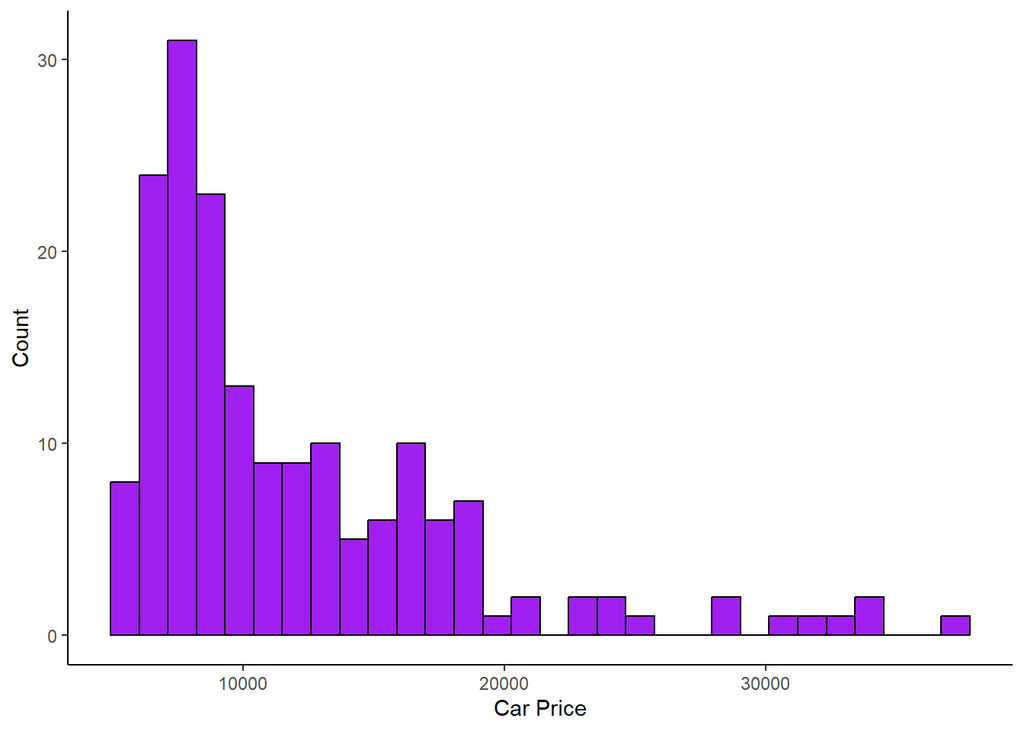

```r
ggplot(data= car_nooutliers, aes(x=price)) +
  geom_histogram(color="black", fill = "purple") +
  xlab("Car Price") +
  ylab ("Count") +
  theme_classic()
```

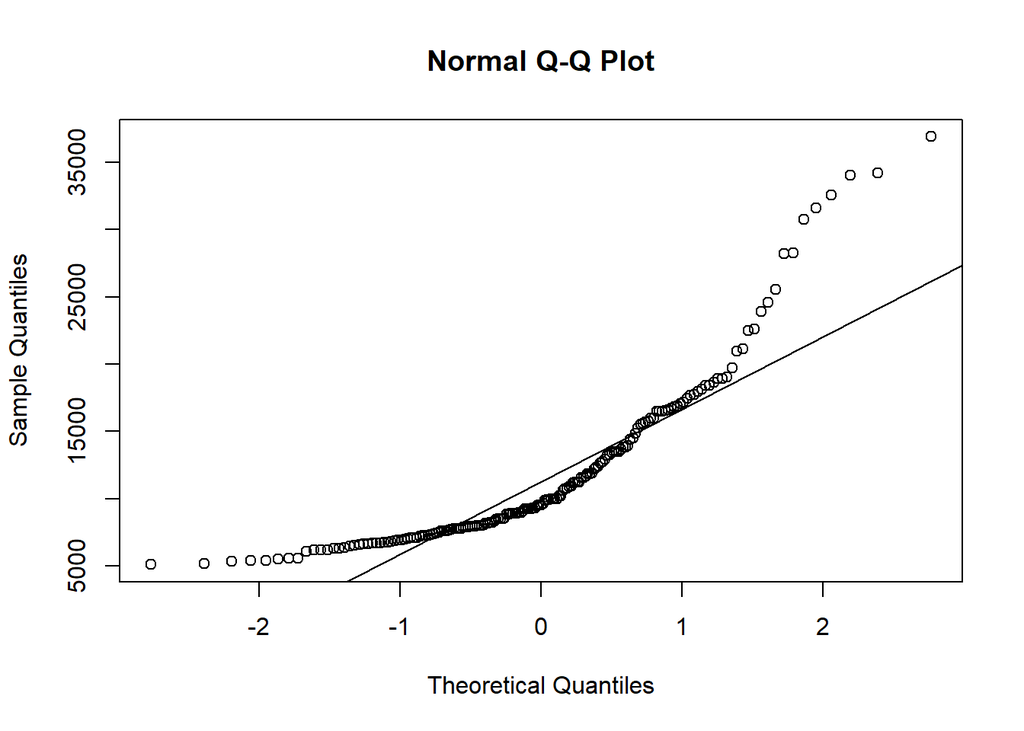

```r
{qqnorm(car_nooutliers$price)
qqline(car_nooutliers$price)}
```

```r
Skew_price <-skewness(car_nooutliers$price)
print(paste("Skewness of car price: ",Skew_price))
```

```
## [1] "Skewness of car price:  1.72585055707673"
```

```r
Kurt_price <- kurtosis(car_nooutliers$price)
print(paste("Kurtosis of car price: ", Kurt_price))
```

```
## [1] "Kurtosis of car price:  6.11028130958224"
```

The first step in exploratory data analysis was to evaluate the dependent variable of price by creating a histogram and Normal Q-Q plot The car price varies in the range of 5118 and 36880.

From the histogram, I found that the price variable was extremely positively skewed which is confirmed by the value of skewness and kurtosis.

Skewness measure a degree of asymmetry of data distribution that deviates from the symmetrical normal distribution. The value of skewness at 1.726 shows that the data are extremely skewed.

Kurtosis measures the heaviness of a distribution’s tails relative to a normal distribution. Since the standard normal distribution has kurtosis of 3, the kurtosis value at 6.11 (excess kurtosis is at 3.11) indicating an extremely positive Kurtosis, or leptokurtic distribution. Positive kurtosis describes a heavier tails and more peaked distributed data

### 5.2 Evaluating independent variables

#### 5.2.1 Categorical variables

The categorical variables include CarCompany, symboling, fueltype,aspiration, doornumber, carbody, drivewheel, enginelocation, enginetype, cylindernumber,fuelsystem.

[figure not shown]

[figure not shown]

```r
cleanup <- theme(panel.grid.major = element_blank(),
                 panel.grid.minor = element_blank(),
                 panel.background = element_blank(),
                 axis.line.x = element_line(color = 'black'),
                 axis.line.y = element_line(color = 'black'),
                 legend.key = element_rect(fill = 'white'),
                 text = element_text(size = 11))

#define function to visualize boxplot and bar graph of categorical variables
car_box_plot<- function(column)
  {
  box_plot<- ggplot(car_nooutliers, aes(y = price, x = .data[[column]],fill = .data[[column]]))+
    geom_boxplot(color = "black") +
    ggtitle(paste(toTitleCase(column), "vs Price")) +
    ylab ("Car Price") +
    xlab (toTitleCase(column)) +
    cleanup +
    scale_fill_viridis(discrete = TRUE) +
    theme(plot.title = element_text(face = "bold", size = 15, hjust = 0.5))
  gridExtra::grid.arrange(box_plot, ncol = 1)
  }

car_bar<- function(column)
{
  car_bar <-  ggplot(car_nooutliers, aes(x = .data[[column]], fill = .data[[column]])) +
    geom_bar () +
    ggtitle(paste("Distribution of ",toTitleCase(column))) +
    xlab(toTitleCase(column))+
    ylab ("Count") +
    cleanup +
    scale_fill_viridis(discrete = TRUE) +
    theme(plot.title = element_text(face = "bold", size = 15, hjust = 0.5))

  gridExtra::grid.arrange(car_bar, ncol = 1)
}
```

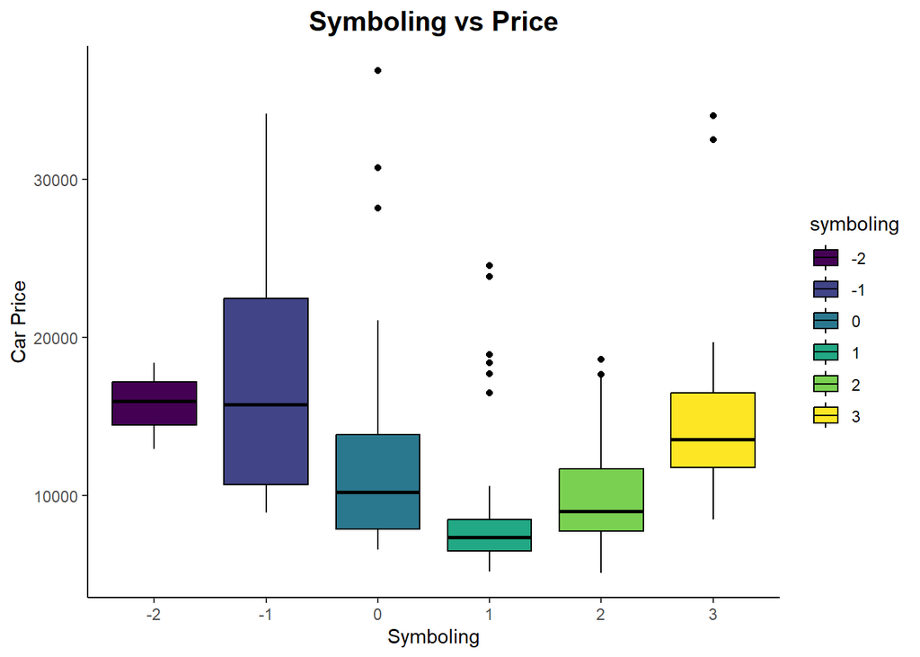

```r
car_box_plot("symboling")
```

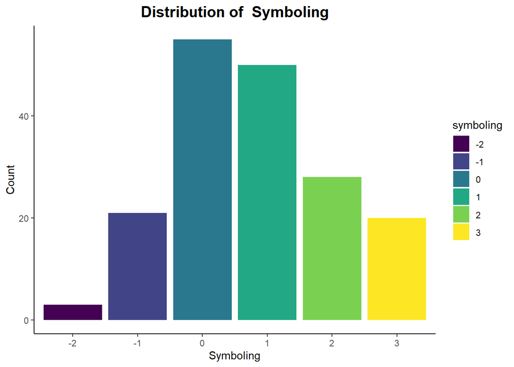

```r
car_bar("symboling")
```

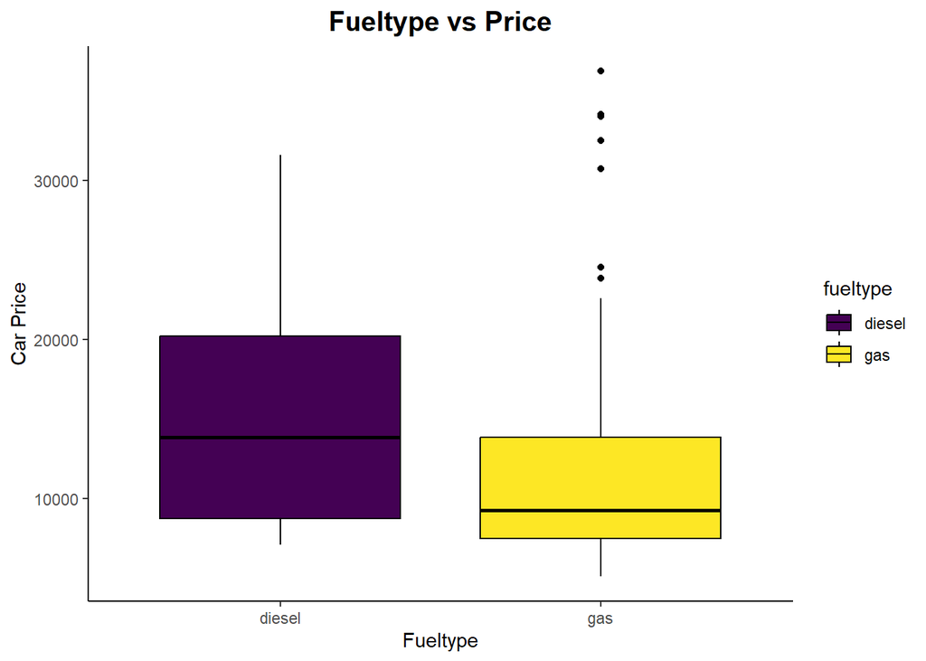

```r
car_box_plot("fueltype")
```

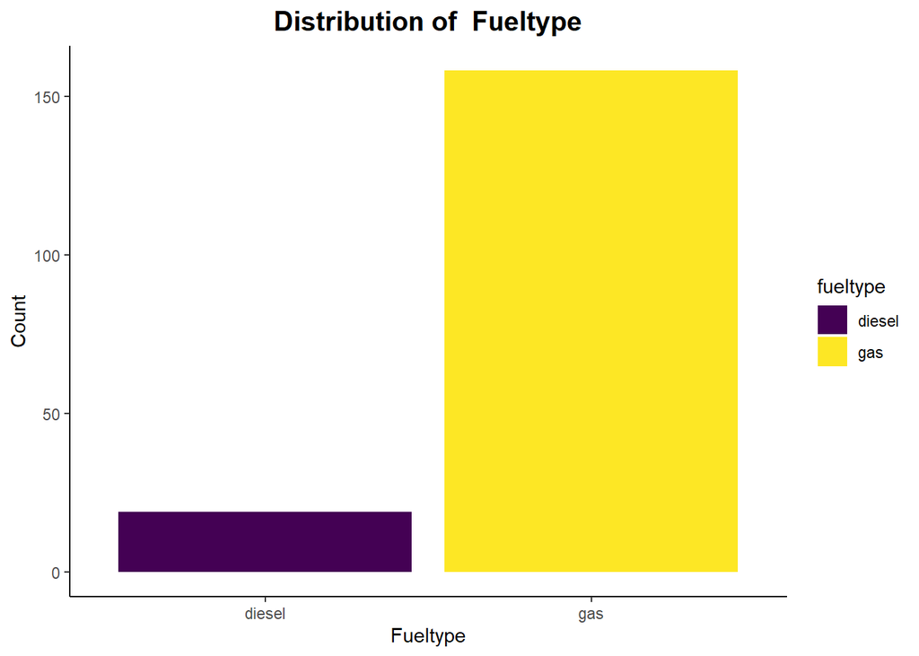

```r
car_bar("fueltype")
```

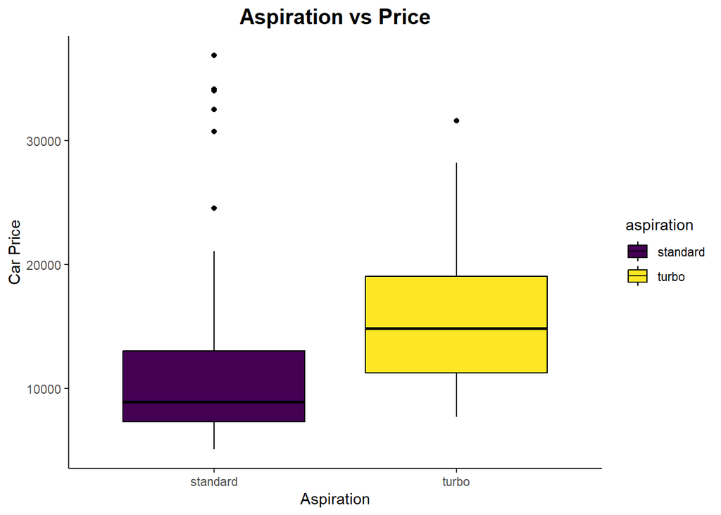

```r
car_box_plot("aspiration")
```

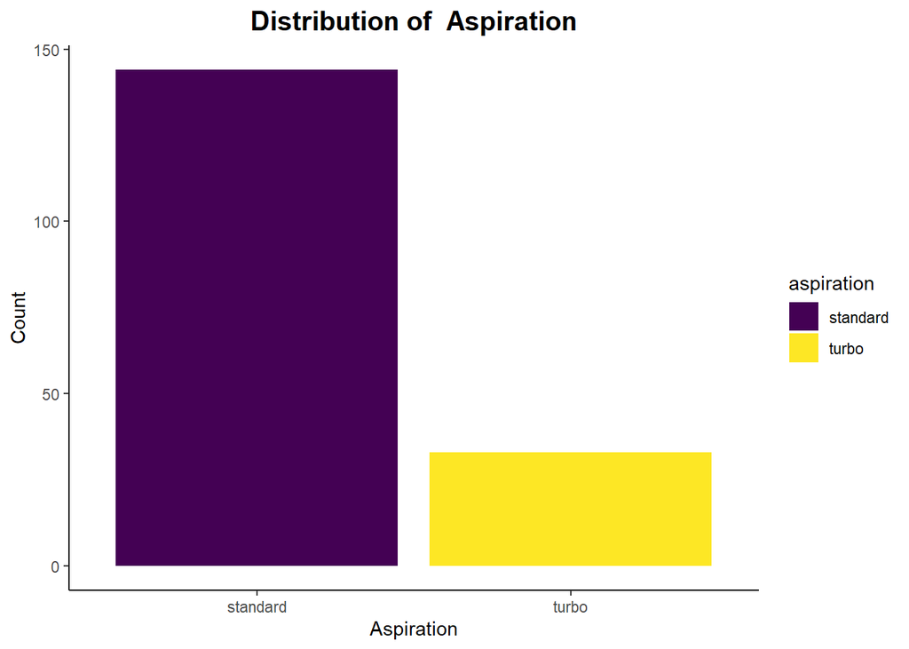

```r
car_bar("aspiration")
```

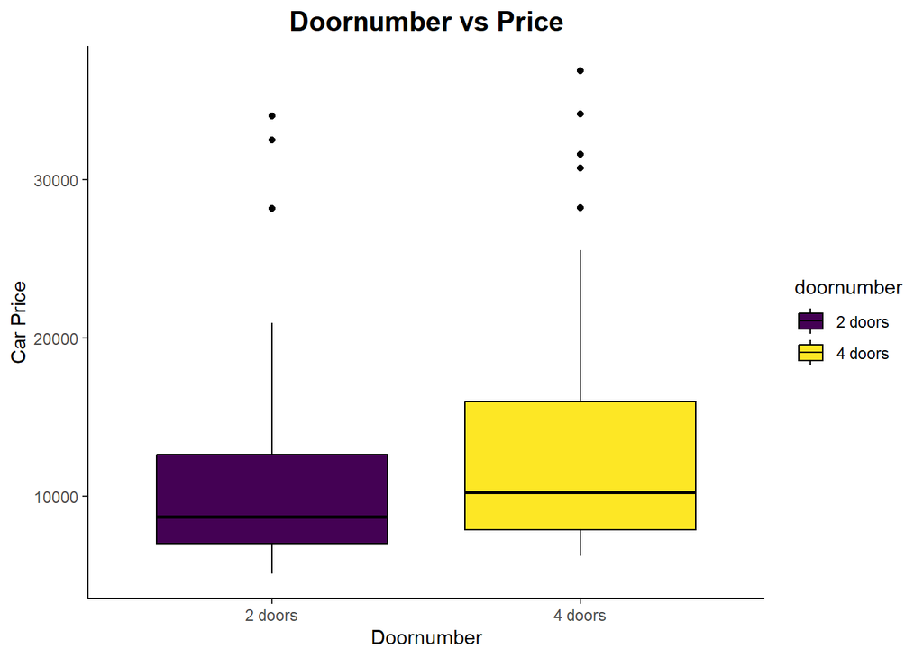

```r
car_box_plot("doornumber")
```

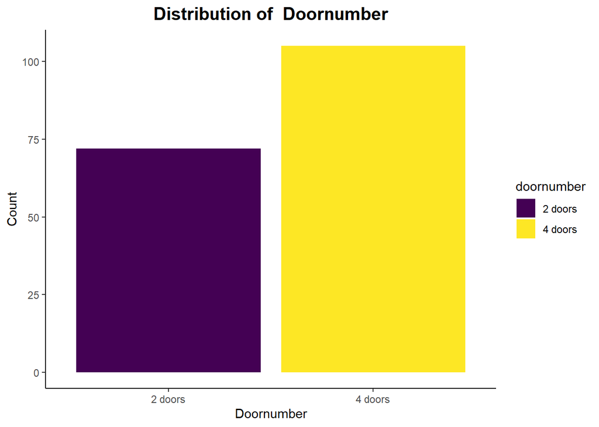

```r
car_bar("doornumber")
```

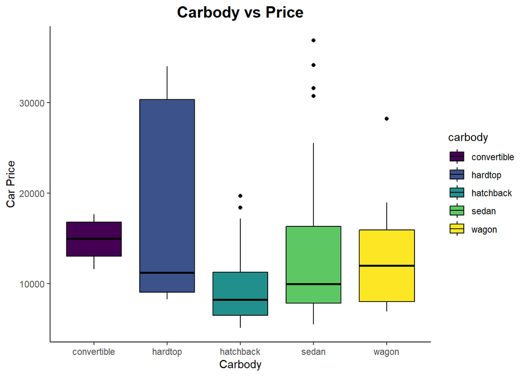

```r
car_box_plot("carbody")
```

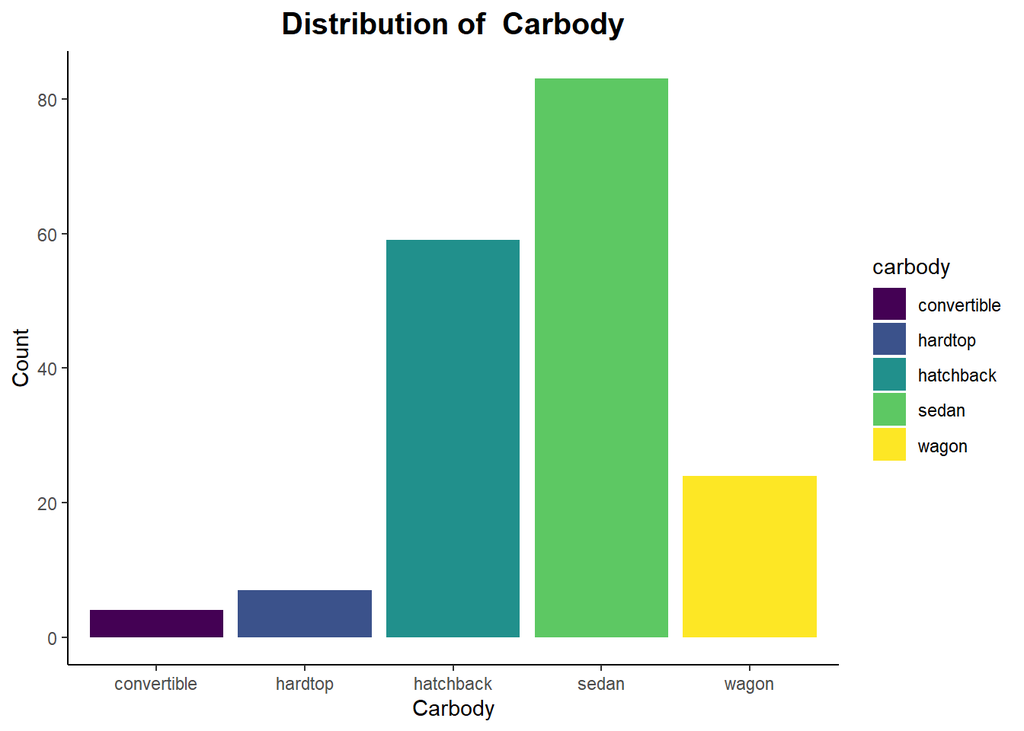

```r
car_bar("carbody")
```

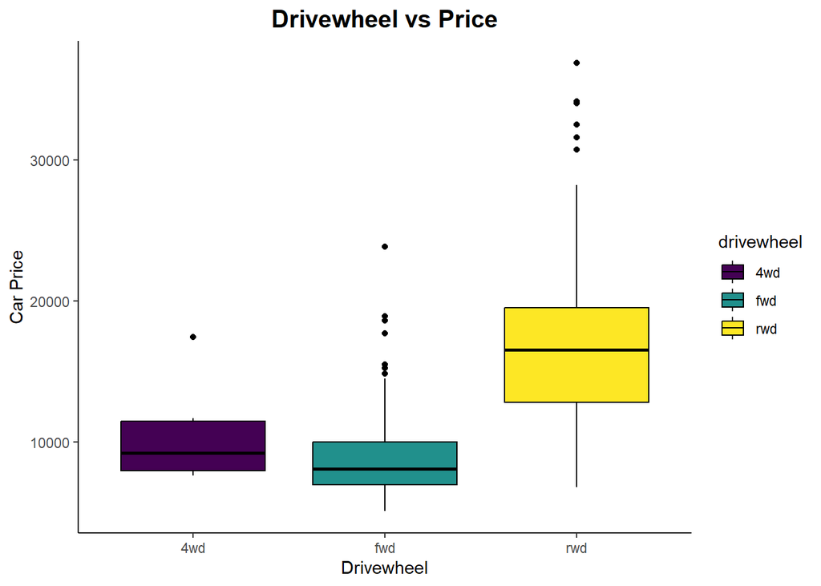

```r
car_box_plot("drivewheel")
```

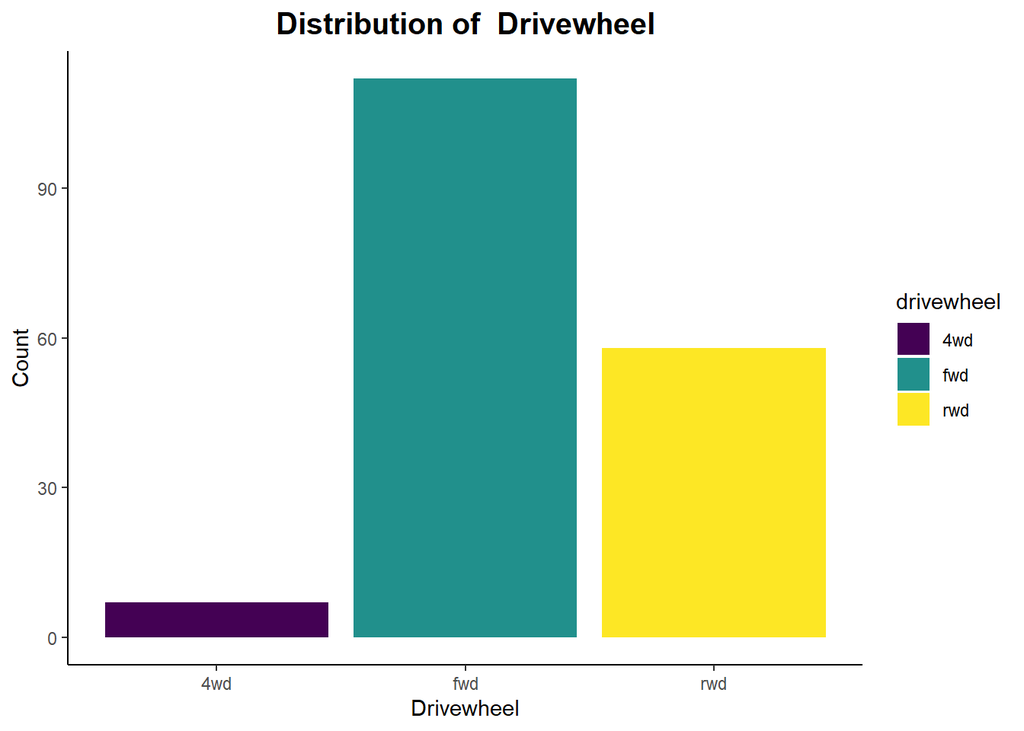

```r
car_bar("drivewheel")
```

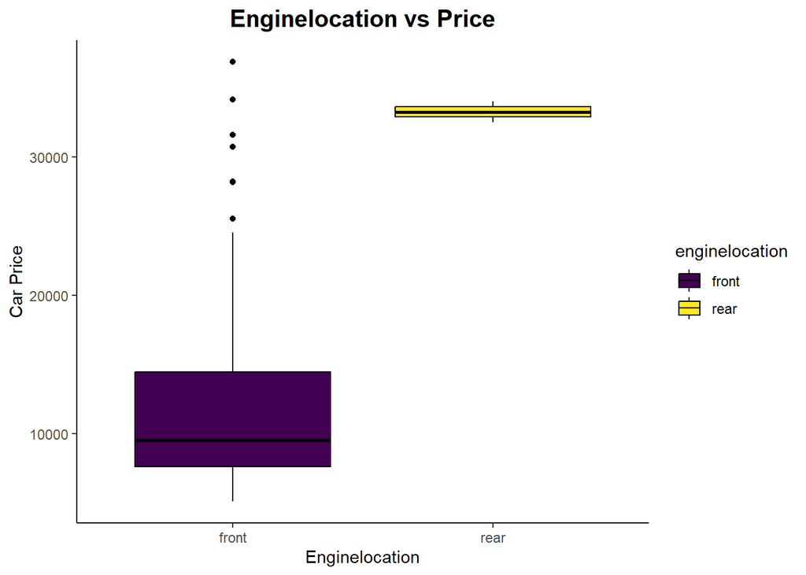

```r
car_box_plot("enginelocation")
```

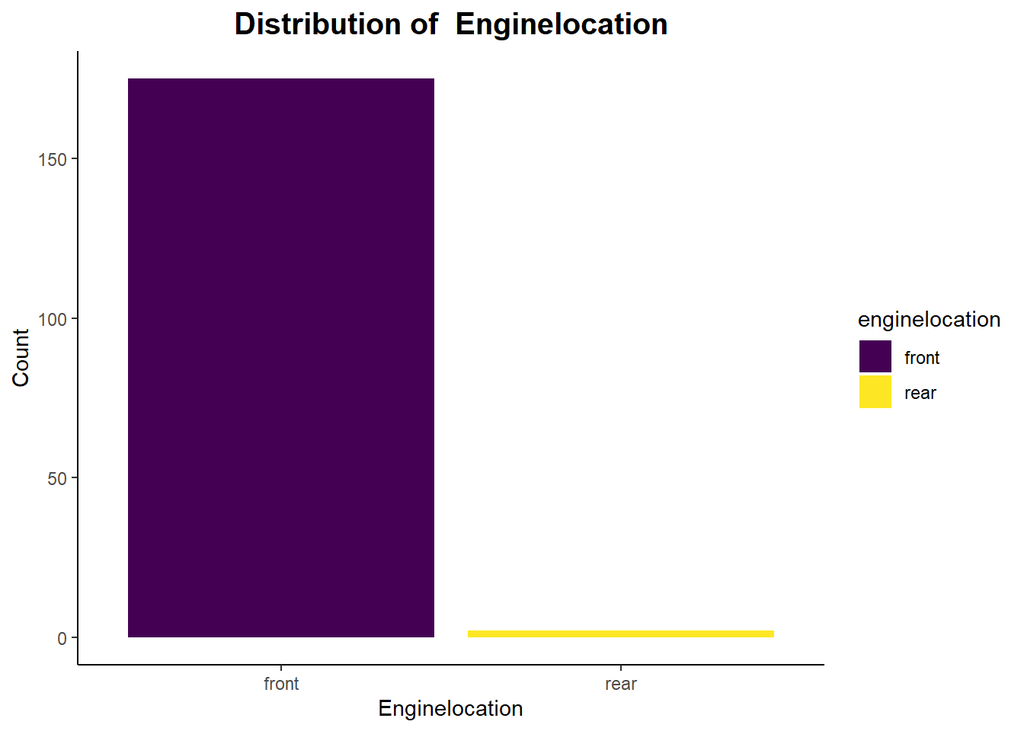

```r
car_bar("enginelocation")
```

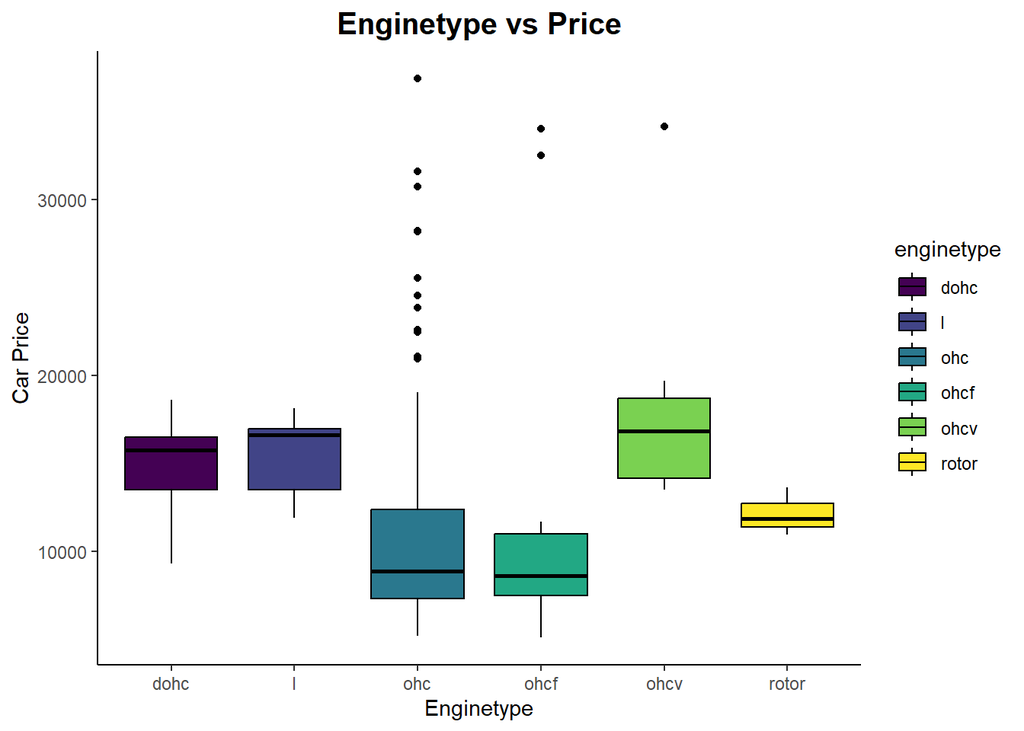

```r
car_box_plot("enginetype")
```

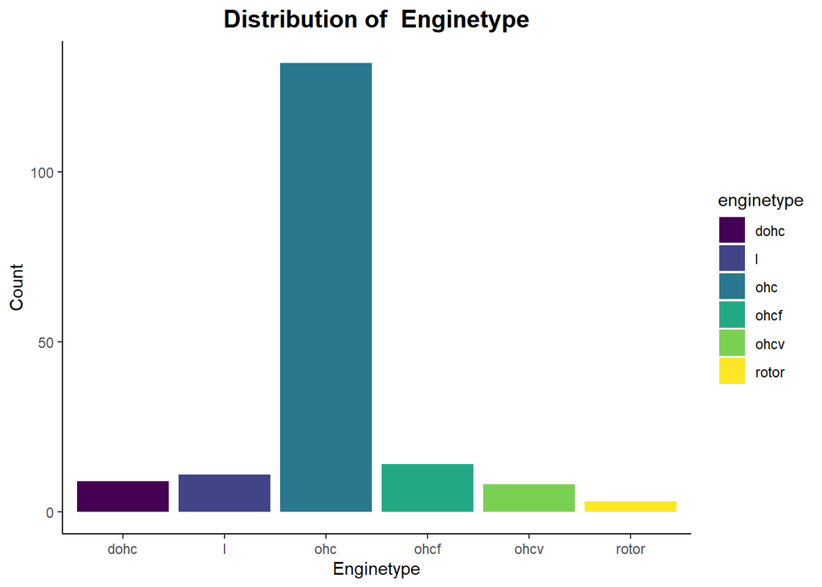

```r
car_bar("enginetype")
```

Engine type ohc has most observations.

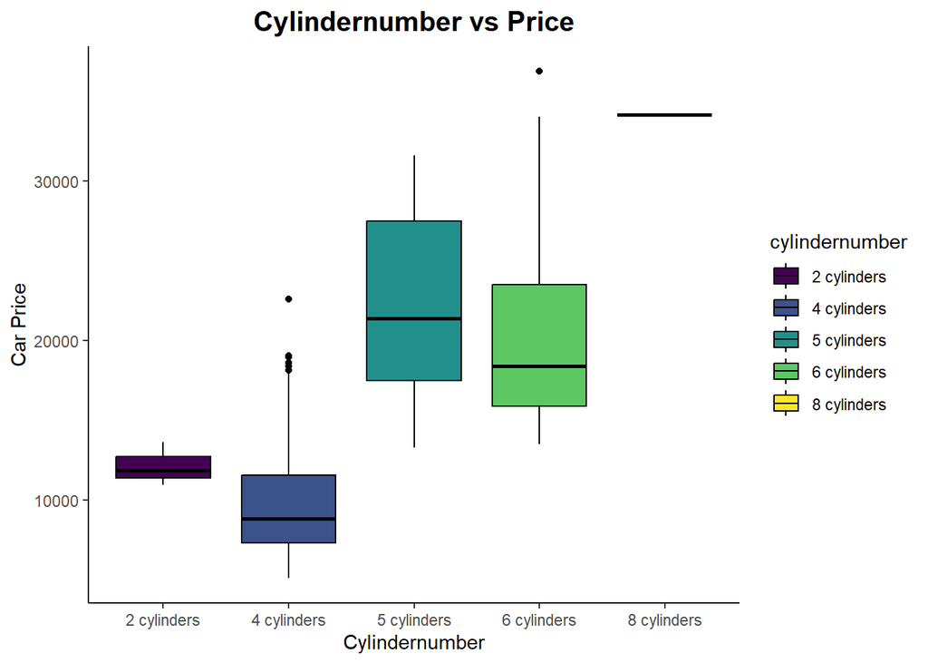

```r
car_box_plot("cylindernumber")
```

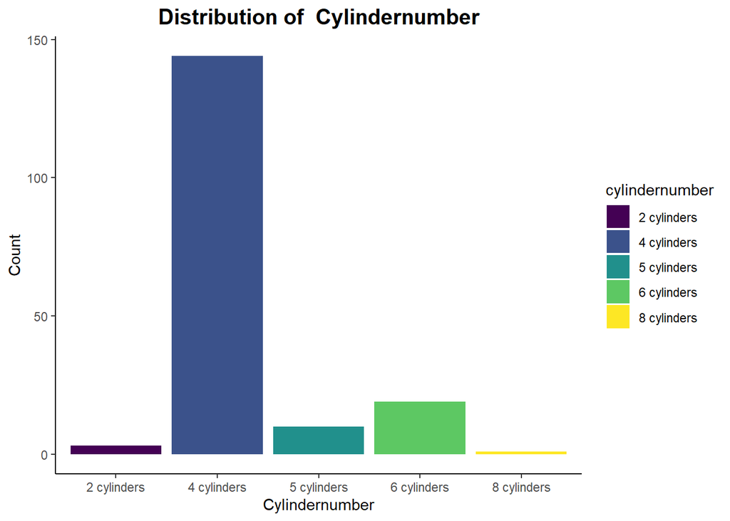

```r
car_bar("cylindernumber")
```

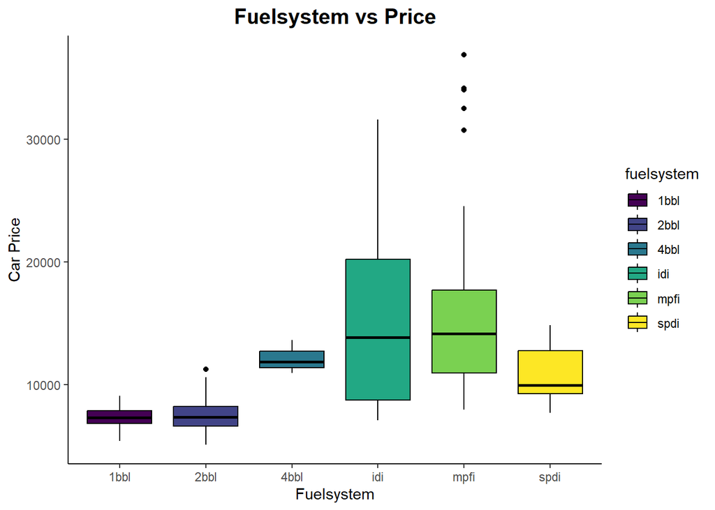

```r
car_box_plot("fuelsystem")
```

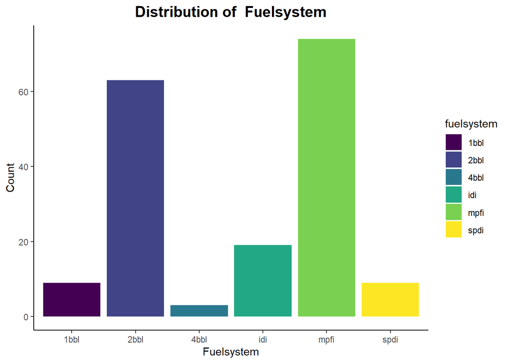

```r
car_bar("fuelsystem")
```

#### 5.2.2 Numerical variables

There are 13 Numerical Independent variables including wheelbase, carlength, carwidth, carheight, curbweight, enginesize,boreratio, stroke, comprressionratio, horsepower, peakrpm, citympg, highwaympg

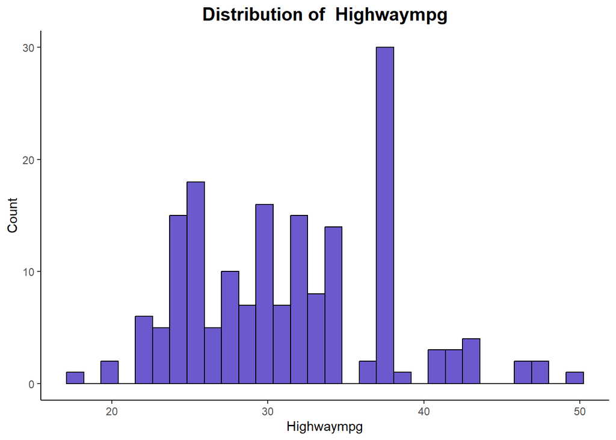

```r
#define function to visualize histogram and scatter plot of numerical variables

car_hist<- function(column)
{
  car_hist <-  ggplot(car_nooutliers, aes(x = .data[[column]])) +
    geom_histogram (color = ' black', fill = 'slateblue') +
    ggtitle(paste("Distribution of ",toTitleCase(column))) +
    xlab(toTitleCase(column))+
    ylab ("Count") +
    theme(plot.title = element_text(face = "bold", size = 15, hjust = 0.5))+
    cleanup

  gridExtra::grid.arrange(car_hist, ncol = 1)
}
car_hist("highwaympg")
```

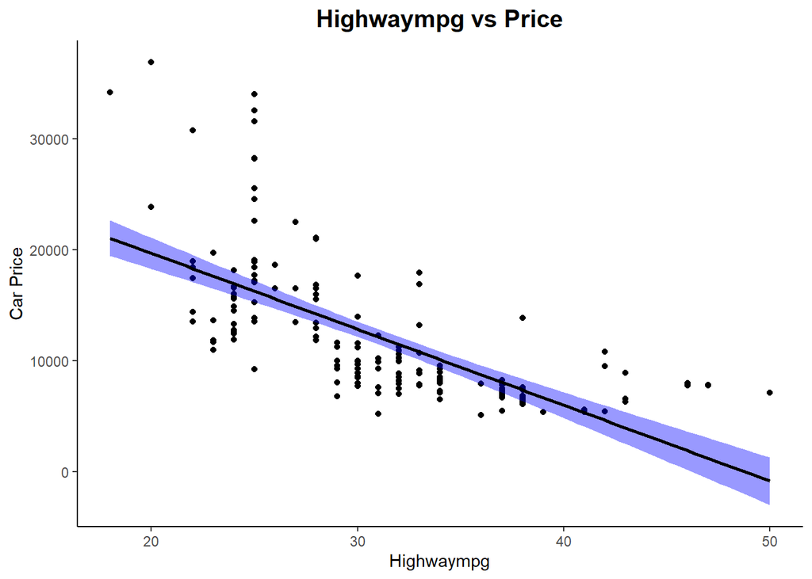

```r
car_scatter_plot<- function(column)
  {
  scatter_plot<- ggplot(car_nooutliers, aes(y = price, x = .data[[column]]))+
    geom_point() +
    geom_smooth(method = 'lm',color='black', fill='blue')+
    ggtitle(paste(toTitleCase(column), "vs Price")) +
    ylab ("Car Price") +
    xlab (toTitleCase(column)) +
    theme_classic() +
    theme(plot.title = element_text(face = "bold", size = 15, hjust = 0.5))+
    cleanup

  gridExtra::grid.arrange(scatter_plot, ncol = 1)
}
car_scatter_plot("highwaympg")
```

```r
# Define function to calculate skewness and kurtosis
skew_kurt <- function(data, variable_name) {
  skew <- skewness(data[[variable_name]])
  kurt <- kurtosis(data[[variable_name]])

  print(paste("Skewness of", toTitleCase(variable_name), ":", skew))
  print(paste("Kurtosis of", toTitleCase(variable_name), ":", kurt))
}
```

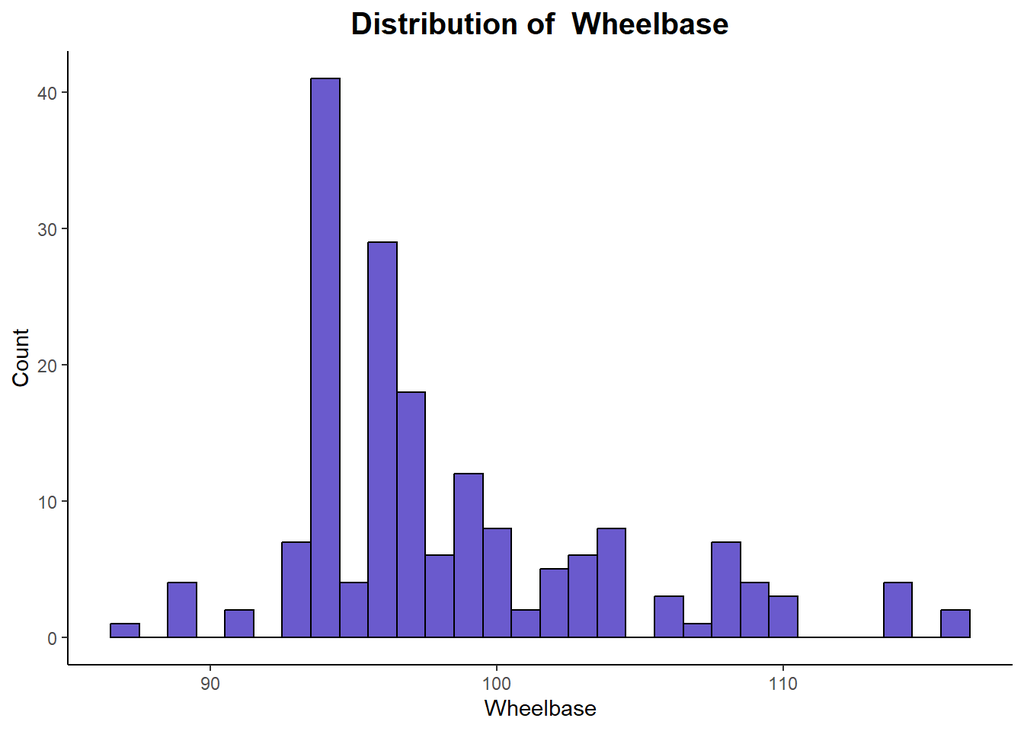

```r
car_hist("wheelbase")
```

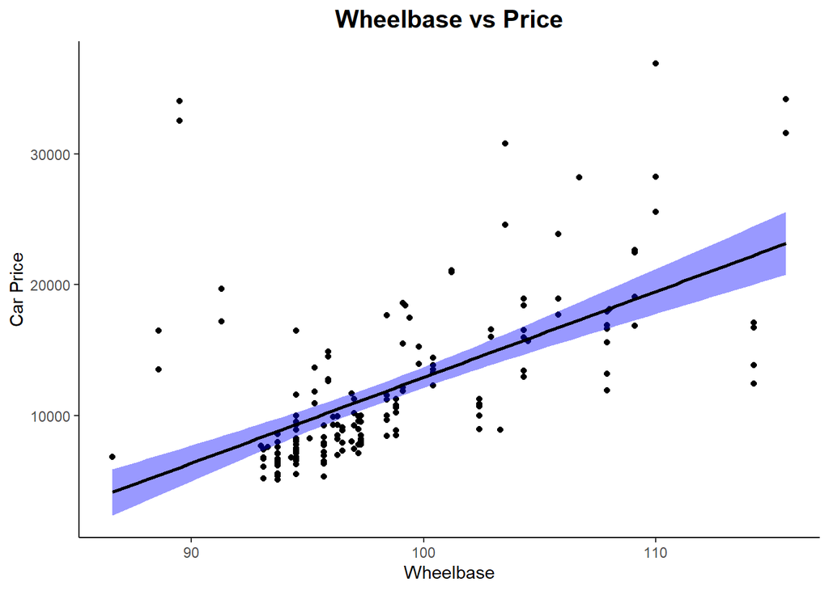

```r
car_scatter_plot("wheelbase")
```

```r
skew_kurt(car_nooutliers, "wheelbase")
```

```
## [1] "Skewness of Wheelbase : 1.06527871977258"
## [1] "Kurtosis of Wheelbase : 3.77509732335759"
```

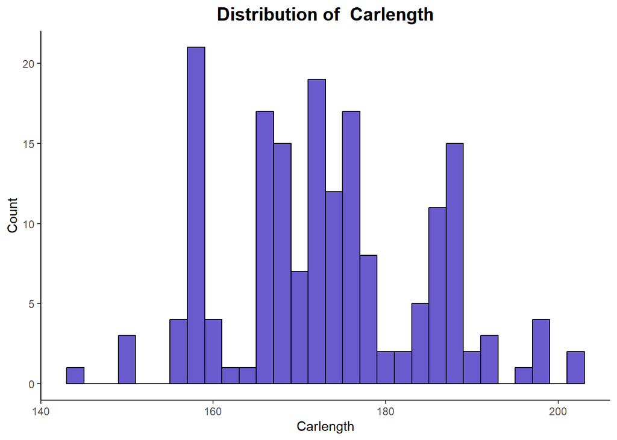

```r
car_hist("carlength")
```

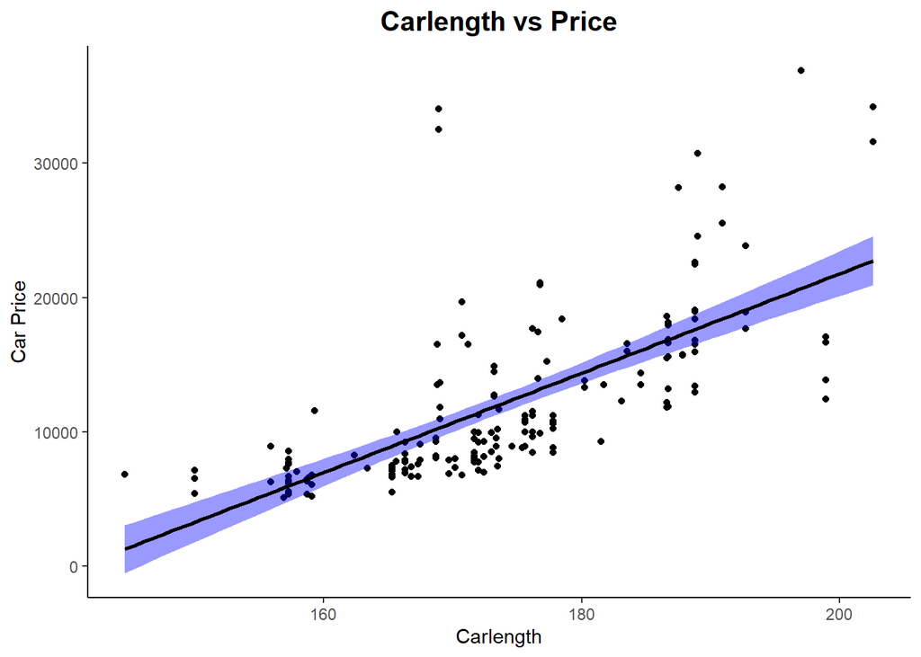

```r
car_scatter_plot("carlength")
```

```r
skew_kurt(car_nooutliers, "carlength")
```

```
## [1] "Skewness of Carlength : 0.220107390979316"
## [1] "Kurtosis of Carlength : 2.60996261531178"
```

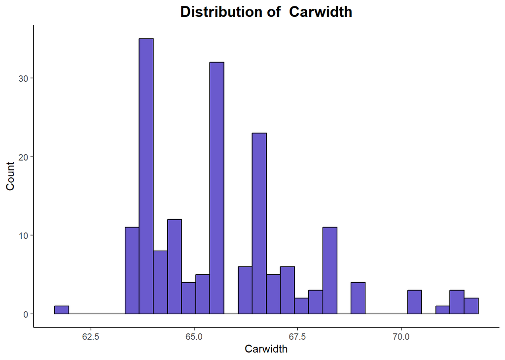

```r
car_hist("carwidth")
```

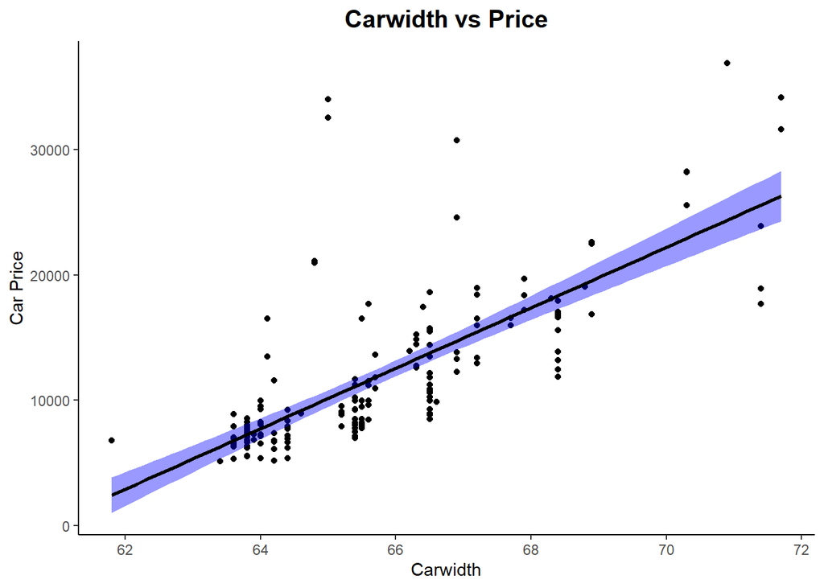

```r
car_scatter_plot("carwidth")
```